# Visualizing Insights: DHDP Federated Learning in the Identification of New Biomarkers for Immunotherapy Response

21 May 2024

# 1 Introduction

In the rapidly evolving field of immuno-oncology, the discovery of effective biomarkers is crucial for advancing personalized treatment strategies. This section explores how Federated Learning (FL) facilitates the identification of new biomarkers for immunotherapy responses. We focus on visualizing FL data to uncover patterns and insights that traditional analyses might miss. Through detailed visual representations, researchers and clinicians can better understand the effectiveness of different biomarkers and optimize therapeutic approaches accordingly. Here, we demonstrate how visualization techniques applied to FL data can highlight pivotal trends and interactions, driving forward the development of targeted immunotherapy treatments.

# 2 Loading Functions

First, we load the necessary libraries and functions into the workspace.

# 3 Load federated learning data

We load the FL data shared by the DHDP FL team. This process involves retrieving datasets that are distributed across various institutions without compromising data privacy. We have loaded results for per-cancer melanoma immunotherapy associations.

```r
# load per-cancer melanoma
res.percan <- read.csv(file.path(dir, "per_cancer_melanoma_result.csv"))
```

# 4 Volcano Plots of Immunotherapy TIGIT Biomarker Associations

We utilize volcano plots to visually represent the results of our analysis on immunotherapy biomarker associations. By plotting the negative log of the p-value against the effect size (i.e., logOR), these plots help us quickly identify biomarkers that show potentially significant differences in response to immunotherapy.

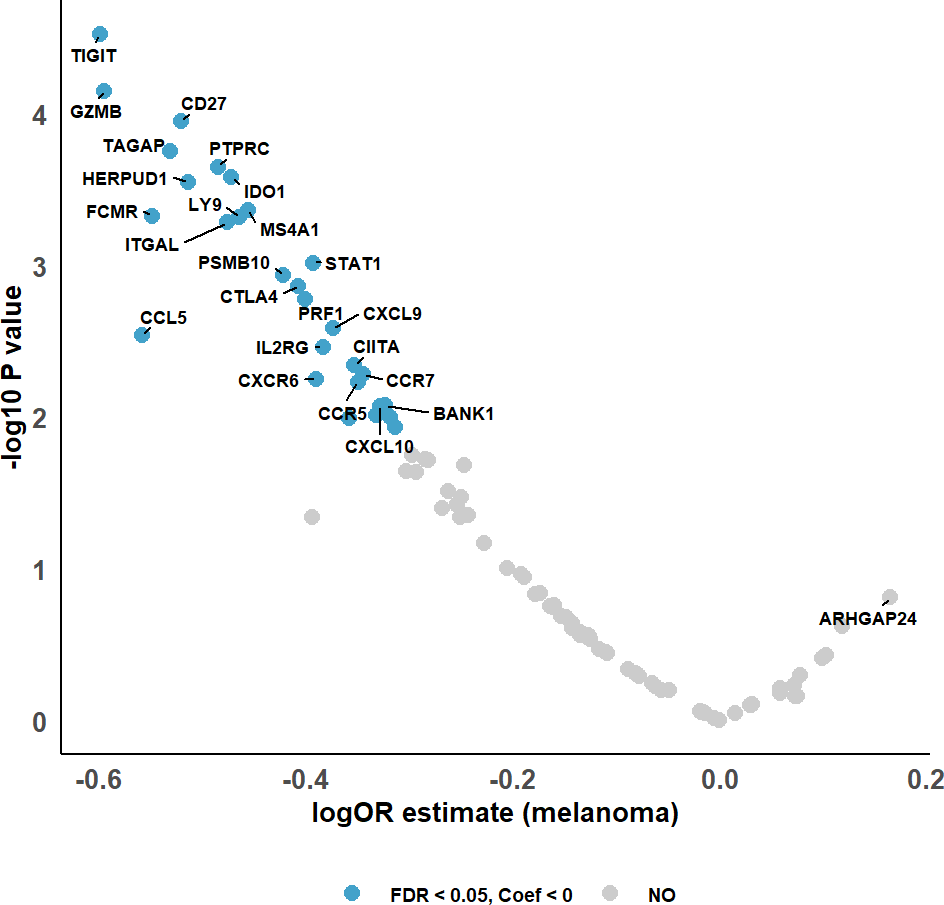

Figure 1: Immunotherapy biomarker associations

```r
volcanoPlot(feature = df.percan.melanoma$Gene,
              coef = df.percan.melanoma$coef.FL,
              pval = df.percan.melanoma$Pval.FL,
              padj = df.percan.melanoma$FDR.FL,
              neg.cutoff = 24,
              pos.cutoff = 1,
              x.lab = "logOR estimate (melanoma)",
              padj.label = TRUE,
              cutoff = 0.05)
```

# 5 Forestplot plots of Immunotherapy TIGIT Biomarker Associations

We present forest plots to summarize the associations between the TIGIT biomarker and its impact on immunotherapy responses across per-cancer melanoma. We aim to facilitate a better understanding of how TIGIT correlations vary with patient responses to treatment across different immunotherapy studies.

## 5.1 per-cancer: melanoma

In the per-cancer melanoma analysis, TIGIT is negatively associated with immunotherapy response (logOR = -0.54, p = 0.03), with no significant heterogeneity observed across studies.

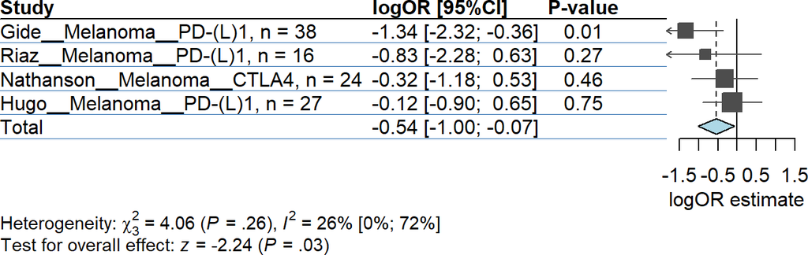

Figure 2: TIGIT association with immunotherpay response: per-cancer melanoma

```r
df <- res.assoc[res.assoc$Gene == "TIGIT", ]
df.melanoma <- df[df$Cancer_type == "Melanoma", ]

forestPlot(coef = df.melanoma$Coef,
           se = df.melanoma$SE,
           study  = df.melanoma$Study,
           pval = df.melanoma$Pval,
           n = df.melanoma$N,
           cancer.type = do.call(rbind, strsplit(df.melanoma$Study, split='__', fixed=TRUE))[, 2],
           treatment = df.melanoma$Treatment,
           feature = unique(df.melanoma$Gene),
           xlab = "logOR estimate",
           label = "logOR")
```